# yangy22__FinalHomeworkCode_03

[figure not shown]

```r
library(curl)
f<- curl("https://raw.githubusercontent.com/fuzzyatelin/fuzzyatelin.github.io/master/AN588_Fall23/zombies.csv")
d <- read.csv(f, header = TRUE, sep = ",", stringsAsFactors = FALSE)
```

## Question 1

Calculate the population mean and standard deviation for each quantitative random variable (height, weight, age, number of zombies killed, and years of education). NOTE: You will not want to use the built in var() and sd() commands as these are for samples.

```r
Mean <- c(mean(d$height), mean(d$weight), mean(d$age), mean(d$zombies_killed), mean(d$years_of_education)) #Put all the means in one object
h <- sqrt(sum((d$height - mean(d$height))^2)/length(d$height)) # calculate SD separately for each of the variables
w <- sqrt(sum((d$weight - mean(d$weight))^2)/length(d$weight))
a <- sqrt(sum((d$age - mean(d$age))^2)/length(d$age))
z <-sqrt(sum((d$zombies_killed - mean(d$zombies_killed))^2)/length(d$zombies_killed))
y <- (sum((d$years_of_education - mean(d$years_of_education))^2)/length(d$years_of_education))
SD <- c(h,w,a,z,y) # Put all of the SD in an object

New <- rbind(Mean, SD) # combine mean and SD
colnames(New) <- c("Height","Weight", "Age", "Zombies Killed", "Years of Education") # Rename columns
New
```

[output not shown]

## Question 2

Use {ggplot} to make boxplots of each of these variables by gender.

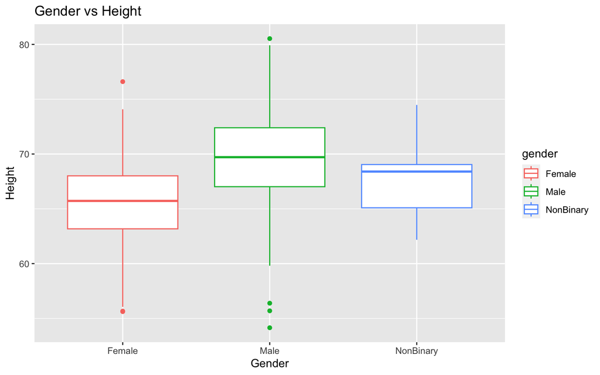

```r
library(ggplot2)
p <- ggplot(d, aes(x=gender, y=height, color=gender)) + geom_boxplot() #color each boxplot
p + ggtitle("Gender vs Height") + xlab("Gender") + ylab("Height") # Add axis labels
```

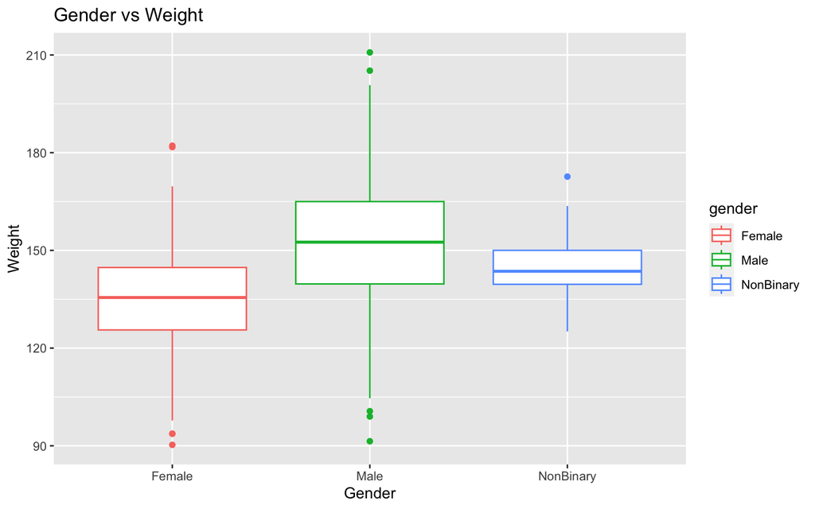

```r
q <- ggplot(d, aes(x=gender, y=weight, color=gender)) + geom_boxplot()
q + ggtitle("Gender vs Weight") + xlab("Gender") + ylab("Weight")
```

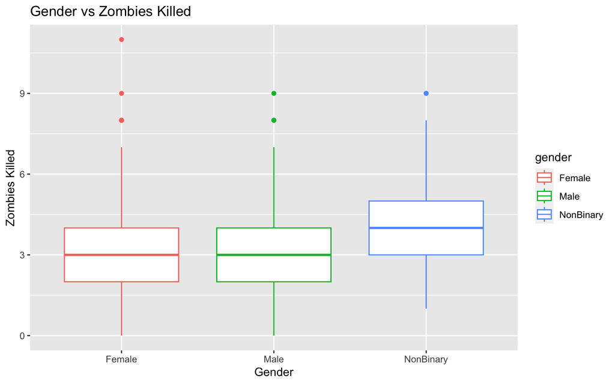

```r
r <- ggplot(d, aes(x=gender, y=zombies_killed, color=gender)) + geom_boxplot()
r + ggtitle("Gender vs Zombies Killed") + xlab("Gender") + ylab("Zombies Killed")
```

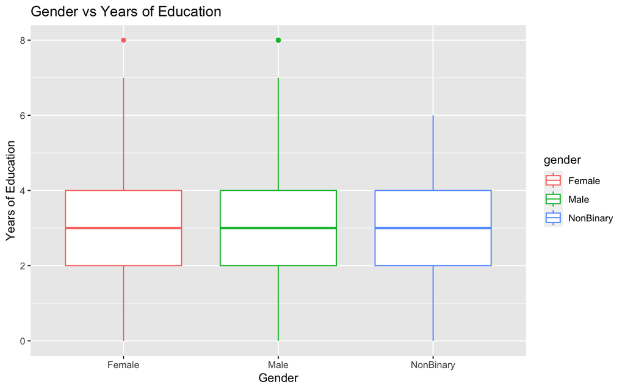

```r
s <- ggplot(d, aes(x=gender, y=years_of_education, color=gender)) + geom_boxplot()
s + ggtitle("Gender vs Years of Education") + xlab("Gender") + ylab("Years of Education")
```

## Question 3

Use {ggplot} to make scatterplots of height and weight in relation to age. Do these variables seem to be related? In what way?

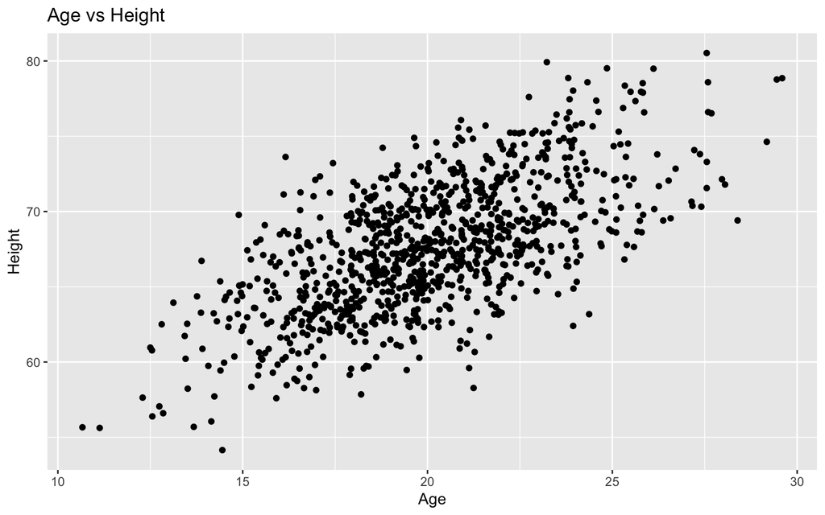

```r
t <- ggplot(d, aes(x=age, y=height)) + geom_point()
t + ggtitle("Age vs Height") + xlab("Age") + ylab("Height")
```

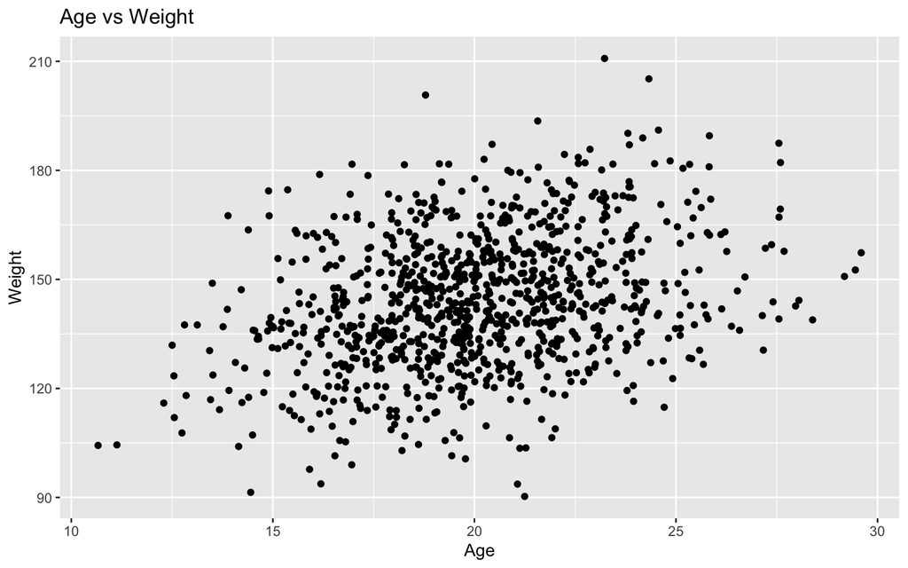

```r
u <- ggplot(d, aes(x=age, y=weight)) + geom_point()
u + ggtitle("Age vs Weight") + xlab("Age") + ylab("Weight")
```

There is a generally positive trend between age and height or weight. This makes sense because kids are shorter and lighter than adults. Zombies survivors have a lot of variety of weights and heights even at the same age probably because of genetics and how much food they could find in the apocalypse.

## Question 4

Using histograms and Q-Q plots, check whether the quantitative variables seem to be drawn from a normal distribution. Which seem to be and which do not (hint: not all are drawn from the normal distribution)? For those that are not normal, can you determine from which common distribution they are drawn?

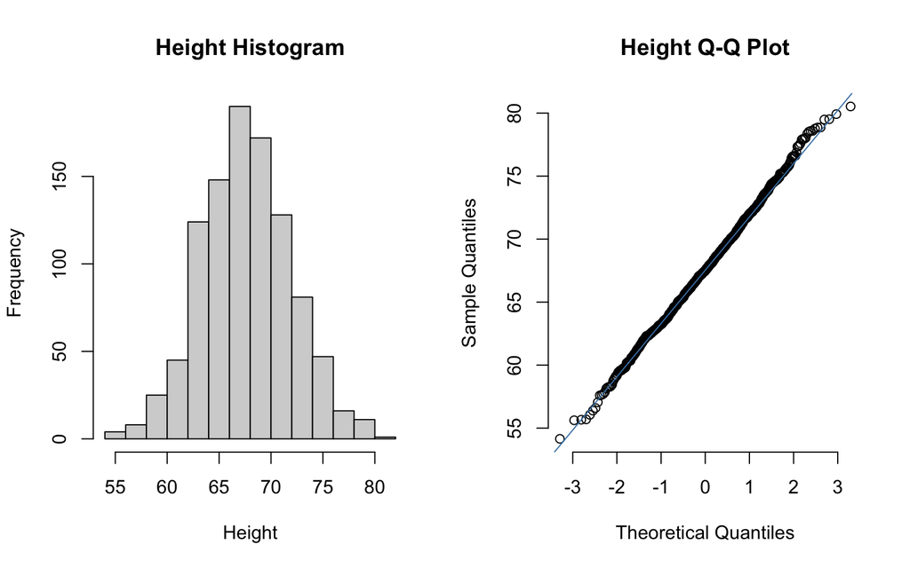

```r
par(mfrow = c(1, 2))
hist(d$height, main = "Height Histogram", xlab= "Height")
qqnorm(d$height, frame = FALSE, main = "Height Q-Q Plot")
qqline(d$height, col = "steelblue")
```

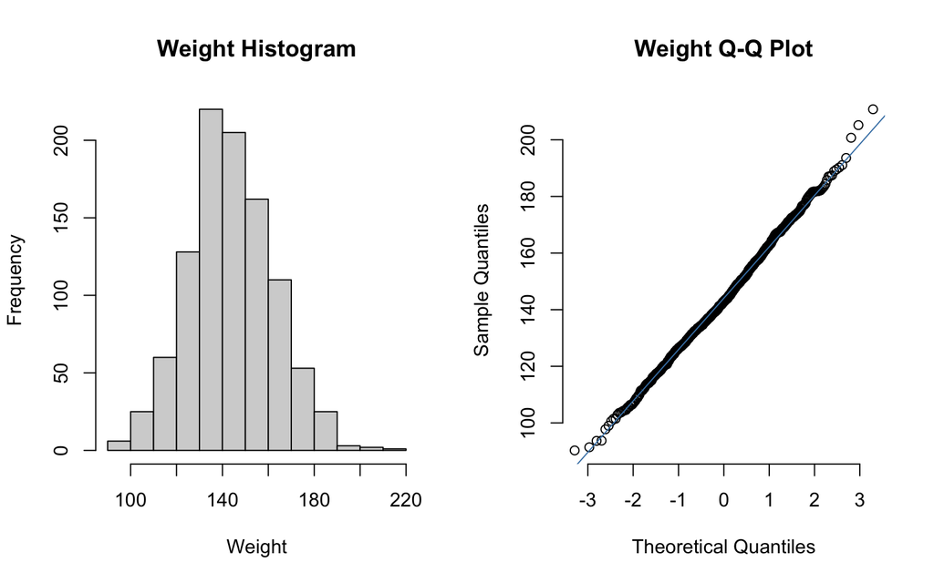

```r
par(mfrow = c(1, 2))
hist(d$weight, main = "Weight Histogram", xlab= "Weight")
qqnorm(d$weight, frame = FALSE, main = "Weight Q-Q Plot")
qqline(d$weight, col = "steelblue")
```

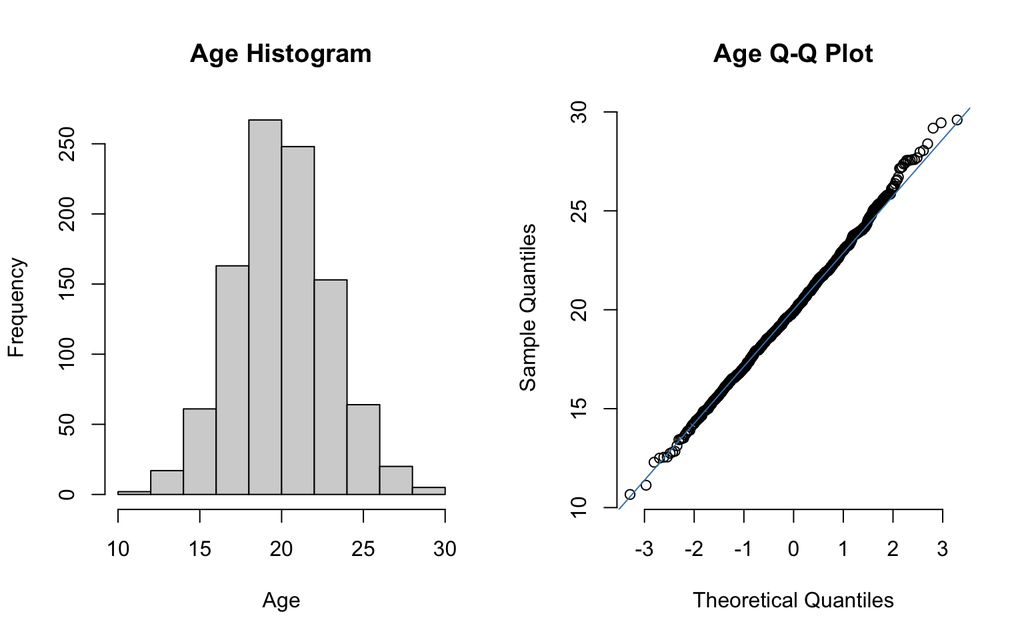

```r
par(mfrow = c(1, 2))
hist(d$age, main = "Age Histogram", xlab= "Age")
qqnorm(d$age, frame = FALSE, main = "Age Q-Q Plot")
qqline(d$age, col = "steelblue")
```

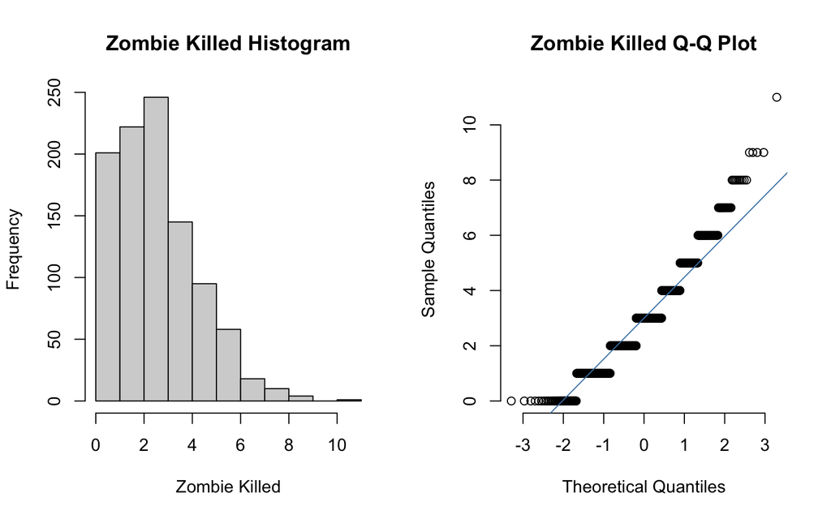

```r
par(mfrow = c(1, 2))
hist(d$zombies_killed, main = "Zombie Killed Histogram", xlab= "Zombie Killed")
qqnorm(d$zombies_killed, frame = FALSE, main = "Zombie Killed Q-Q Plot")
qqline(d$zombies_killed, col = "steelblue")
```

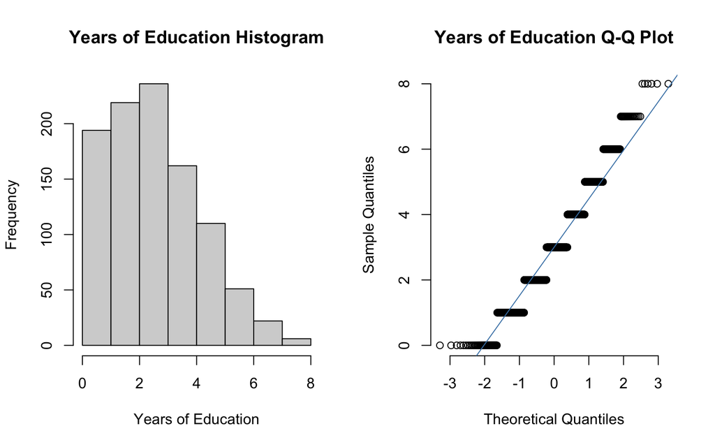

```r
par(mfrow = c(1, 2))
hist(d$years_of_education, main = "Years of Education Histogram", xlab= "Years of Education")
qqnorm(d$years_of_education, frame = FALSE, main = "Years of Education Q-Q Plot")
qqline(d$years_of_education, col = "steelblue")
```

Weight, Height, and Age are normally distributed. Years of education and Zombies Killed are not normally distributed. They are from a Poisson distribution.

## Question 5

Now use the sample() function to sample ONE subset of 30 zombie survivors (without replacement) from this population and calculate the mean and sample standard deviation for each variable. Also estimate the standard error for each variable, and construct the 95% confidence interval for each mean. Note that for the variables that are not drawn from the normal distribution, you may need to base your estimate of the CIs on slightly different code than for the normal…

```r
h<- sample(d$height, size = 30, replace = FALSE, prob = NULL)
m<- mean(h)
sd<- sd(h)
sem <- sd(h)/sqrt(length(h))
lower <- m - qnorm(1 - 0.05/2) * sem  # (1-alpha)/2 each in the upper and lower tails of the distribution
upper <- m + qnorm(1 - 0.05/2) * sem  # (1-alpha)/2 each in the upper and lower tails of the distribution
ci <- c(lower, upper)
Height <-c(m, sd, sem, ci)

h<- sample(d$weight, size = 30, replace = FALSE, prob = NULL)
m<- mean(h)
sd<- sd(h)
sem <- sd(h)/sqrt(length(h))
lower <- m - qnorm(1 - 0.05/2) * sem
upper <- m + qnorm(1 - 0.05/2) * sem
ci <- c(lower, upper)
Weight <-c(m, sd, sem, ci)

h<- sample(d$age, size = 30, replace = FALSE, prob = NULL)
m<- mean(h)
sd<- sd(h)
sem <- sd(h)/sqrt(length(h))
lower <- m - qnorm(1 - 0.05/2) * sem
upper <- m + qnorm(1 - 0.05/2) * sem
ci <- c(lower, upper)
Age <-c(m, sd, sem, ci)

h<- sample(d$zombies_killed, size = 30, replace = FALSE, prob = NULL)
m<- mean(h)
sd<- sd(h)
sem <- sd(h)/sqrt(length(h))
# Winging these confidence intervals
lower <- m - qnorm(1 - 0.05/2) * sem
upper <- m + qnorm(1 - 0.05/2) * sem
ci <- c(lower, upper)
Zkill <-c(m, sd, sem, ci)

h<- sample(d$years_of_education, size = 30, replace = FALSE, prob = NULL)
m<- mean(h)
sd<- sd(h)
sem <- sd(h)/sqrt(length(h))
# Winging these confidence intervals
ci <- c(lower, upper)
Years <-c(m, sd, sem, ci)

New <- rbind(Height, Weight, Age, Zkill, Years)
colnames(New) <- c("Mean", "SD", "SE", "Lower CI", "Upper CI")
New
```

[output not shown]

## Question 6

Now draw 99 more random samples of 30 zombie apocalypse survivors, and calculate the mean for each variable for each of these samples. Together with the first sample you drew, you now have a set of 100 means for each variable (each based on 30 observations), which constitutes a sampling distribution for each variable. What are the means and standard deviations of this distribution of means for each variable? How do the standard deviations of means compare to the standard errors estimated in [5]? What do these sampling distributions look like (a graph might help here)? Are they normally distributed? What about for those variables that you concluded were not originally drawn from a normal distribution?

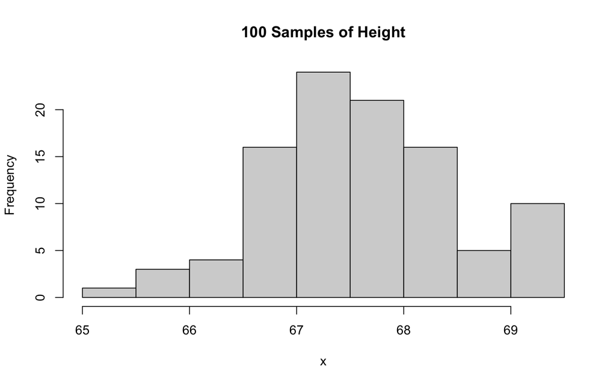

```r
x <- NULL
for (i in 1:100) {
    x[i] <- mean(sample(d$height, size = 30, replace = FALSE, prob = NULL))
}
Height <- c(mean(x),(sd(x)))
hist(x, main = "100 Samples of Height")
```

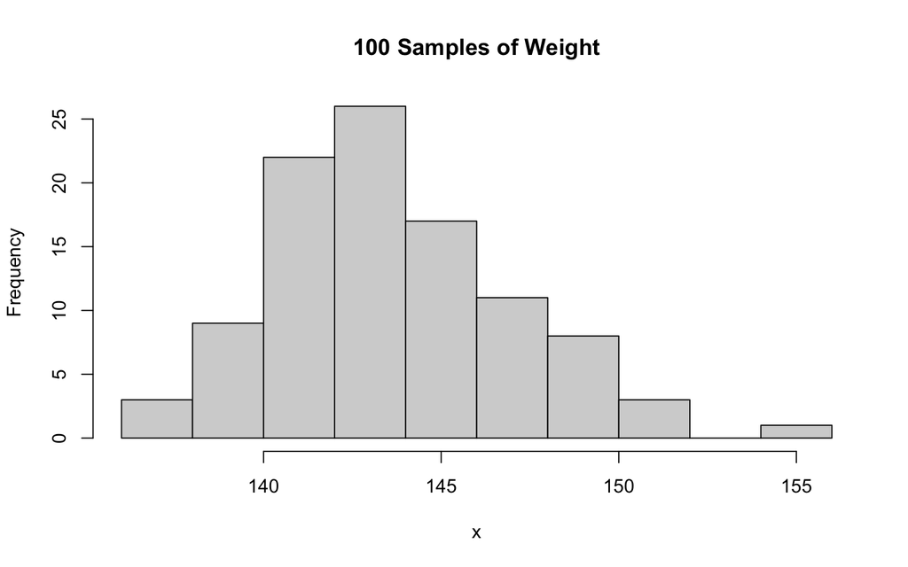

```r
x <- NULL
for (i in 1:100) {
    x[i] <- mean(sample(d$weight, size = 30, replace = FALSE, prob = NULL))
}
Weight <- c(mean(x),(sd(x)))
hist(x, main = "100 Samples of Weight")
```

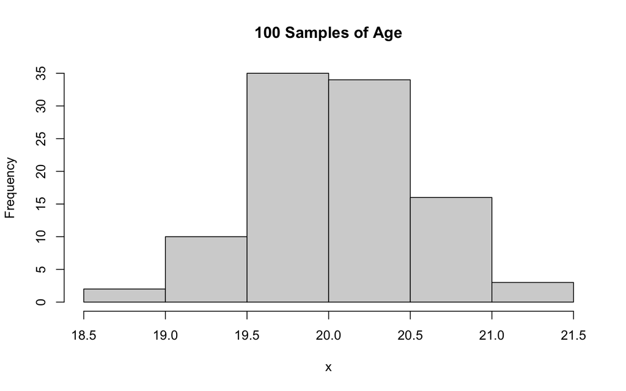

```r
x <- NULL
for (i in 1:100) {
    x[i] <- mean(sample(d$age, size = 30, replace = FALSE, prob = NULL))
}
Age <- c(mean(x),(sd(x)))
hist(x, main = "100 Samples of Age")
```

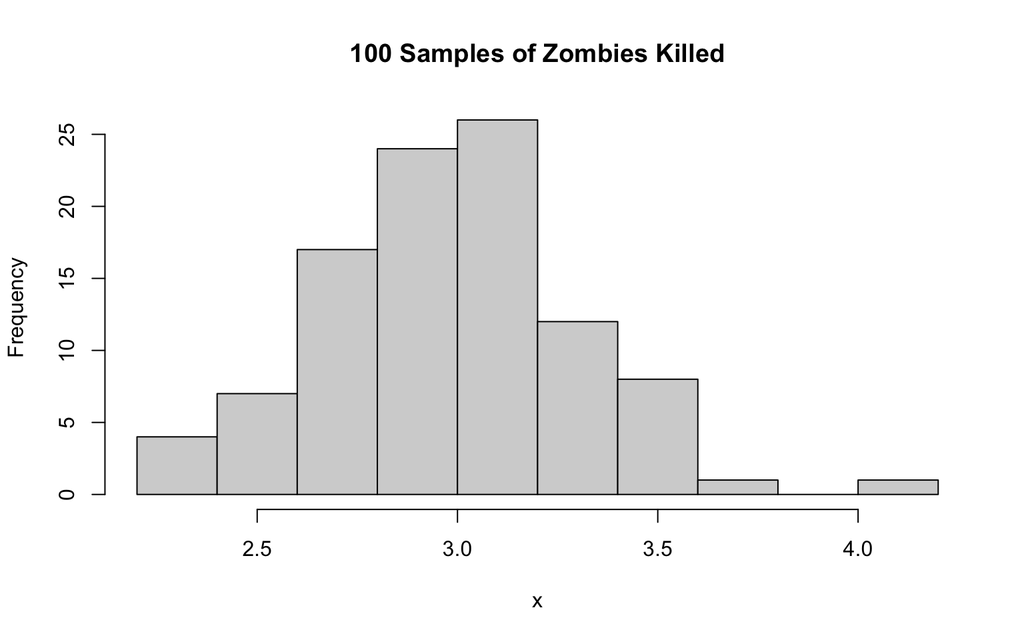

```r
x <- NULL
for (i in 1:100) {
    x[i] <- mean(sample(d$zombies_killed, size = 30, replace = FALSE, prob = NULL))
}
Zkill <- c(mean(x),(sd(x)))
hist(x, main = "100 Samples of Zombies Killed")
```

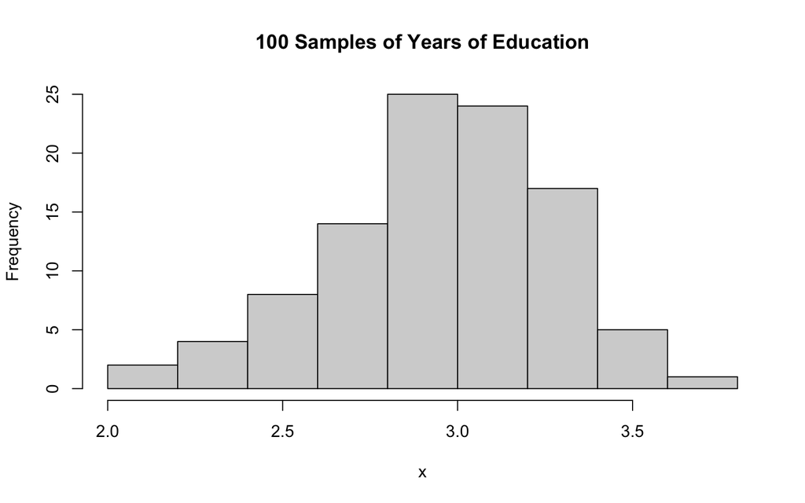

```r
x <- NULL
for (i in 1:100) {
    x[i] <- mean(sample(d$years_of_education, size = 30, replace = FALSE, prob = NULL))
}
Years <- c(mean(x),(sd(x)))
hist(x, main = "100 Samples of Years of Education")
```

```r
New <- rbind(Height, Weight, Age, Zkill, Years)
colnames(New) <- c("Mean", "SD")
New
```

```
##              Mean        SD
## Height  67.613726 0.8784375
## Weight 143.633240 3.3801005
## Age     20.064577 0.5150340
## Zkill    2.999667 0.3246511
## Years    2.970333 0.3245958
```

The distributions look normally distributed even the ones that came from Poisson distributions because we moved the center to be the mean of 30 samples. The means are similar to before but the standard deviation dropped because we averaged between samples.

Reflections added 10/19/23: I had challenges working with the gender and comparing it with the different variables in Question 2. I wanted to separate out the gender groups and then make the graphs and I couldn’t get it to subset. I ended up finding that making it one graph automatically separates out by gender. Which should have been obvious. Another challenge I had was that I didn’t know how to find the CI of the two non-normal distributions. I used the regular CI interval formula for normal distributions. Third challenge was for question 6 I didn’t add the sample from question 5 I just picked 100 new samples. I assumed that since they were picked the same way it shouldn’t change things very much and I didn’t want to try adding data across chunks. I didn’t run into any other challenges.

https://www.datacamp.com/tutorial/subsets-in-r  
http://www.sthda.com/english/wiki/ggplot2-box-plot-quick-start-guide-r-software-and-data-visualization